# Project_3

Somebody

Once upon a time

### Data Description

Data are taken from https://archive.ics.uci.edu/ml/datasets/Mice+Protein+Expression#

We have data with 1080 observations and 82 data about each, includes mouse ID, and metadata about mices Genotype, Treatment group, theirs Behavior and Class. But most of observation are different protein count data. Dbt as we could read from data set description, there are only 72 mices, so from each mouse authors get 15 observations (tissues). Authors purpose that such observations are independent, but it controversial issue. There are 38 control mice and 34 trisomic mice (Down syndrome), totally there are 8 classes of mices (description in table)

| class_name | group | learn | injected | number_of_mice |
| --- | --- | --- | --- | --- |
| c-CS-s | control | stimulated | saline | 9 |
| c-CS-m | control | stimulated | memantine | 10 |
| c-SC-s | control | not stimulated | saline | 9 |
| c-SC-m | control | not stimulated | memantine | 10 |
| t-CS-s | trisomy | stimulated | saline | 7 |
| t-CS-m | trisomy | stimulated | memantine | 9 |
| t-SC-s | trisomy | not stimulated | saline | 9 |
| t-SC-m | trisomy | not stimulated | memantine | 9 |

As we can see that samples are not balanced. most of classes have 9 mice, but there are 2 classes with 10 mice and 1 class (*t-CS-s*) with only 7 mice

### working with missing data (NA)

First of all It is necessary to check data for missing values (NA). Overall there are 1396 missing values

Fortunatly, all factor and character variables have not got na values, so only some protein counts are missed. But there are 528 observation with **NA** , It`s close to half of our observation, so we could not just abort them.

|  | NA_number |
| --- | --- |
| c-CS-m | 210 |
| c-CS-s | 199 |
| c-SC-m | 258 |
| c-SC-s | 120 |
| t-CS-m | 135 |
| t-CS-s | 45 |
| t-SC-m | 225 |
| t-SC-s | 204 |

We can see that in each class there are **NA**. 36 mice have **NA** values, maximum NA for mouse = 129 As about protein counts there are several proteins with high percentage of **NA** values, for them we could not replace them with out great reducing of variety, so we just cast them

| NA_number | names |
| --- | --- |
| 213 | BAD_N |
| 285 | BCL2_N |
| 75 | pCFOS_N |
| 180 | H3AcK18_N |
| 210 | EGR1_N |
| 270 | H3MeK4_N |

| NA_number | obs_numb |
| --- | --- |
| 43 | 3426_13 |
| 43 | 3426_14 |
| 43 | 3426_15 |

### Analis of BDNF_N protein

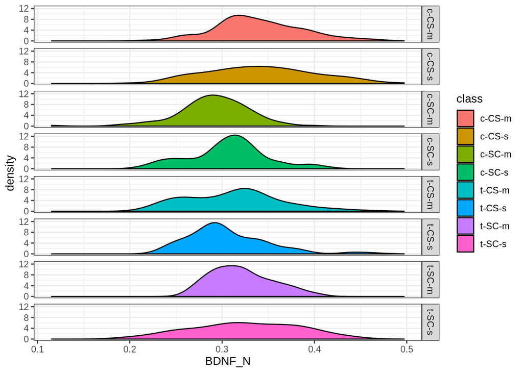

```
##
##  Bartlett test of homogeneity of variances
##
## data:  BDNF_N by class
## Bartlett's K-squared = 67, df = 7, p-value = 7e-12
```

We decided to apply Kruskal-Wallis test.

```
##
##  Kruskal-Wallis rank sum test
##
## data:  BDNF_N by class
## Kruskal-Wallis chi-squared = 118, df = 7, p-value <2e-16
```

As we can see kruskal-wallis test show that there is a difference between groups for BDNF_N protein counts. say that But based on graph we can not understand what groups differ each other

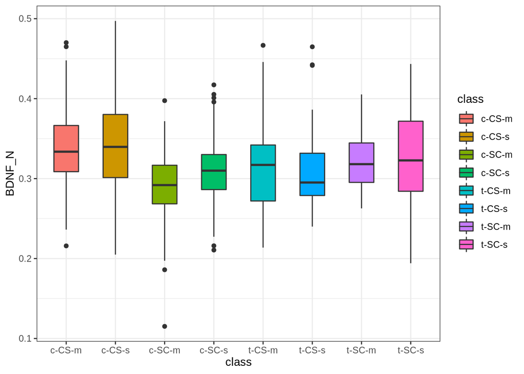

Below table contain only pairs with significant (by DUNN test with Holm-Bonferroni correction). We can see that classes pairs differ each other. we can understand that most difference we find in control groups, between different variant of control and between control and trisomic mice.

|  | Comparison | Z | P.unadj | P.adj |
| --- | --- | --- | --- | --- |
| 1 | c-CS-m - c-SC-m | 8.6 | 0.00 | 0.00 |
| 3 | c-CS-m - c-SC-s | 5.2 | 0.00 | 0.00 |
| 6 | c-CS-m - t-CS-m | 4.5 | 0.00 | 0.00 |
| 9 | c-CS-m - t-CS-s | 6.0 | 0.00 | 0.00 |
| 11 | c-CS-m - t-SC-m | 3.0 | 0.00 | 0.01 |
| 16 | c-CS-m - t-SC-s | 2.4 | 0.02 | 0.03 |
| 2 | c-CS-s - c-SC-m | 8.0 | 0.00 | 0.00 |
| 4 | c-CS-s - c-SC-s | 4.8 | 0.00 | 0.00 |
| 7 | c-CS-s - t-CS-m | 4.2 | 0.00 | 0.00 |
| 10 | c-CS-s - t-CS-s | 5.6 | 0.00 | 0.00 |
| 12 | c-CS-s - t-SC-m | 2.7 | 0.01 | 0.01 |
| 5 | c-SC-m - c-SC-s | -2.9 | 0.00 | 0.01 |
| 8 | c-SC-m - t-CS-m | -3.9 | 0.00 | 0.00 |
| 13 | c-SC-m - t-SC-m | -5.4 | 0.00 | 0.00 |
| 17 | c-SC-m - t-SC-s | -6.0 | 0.00 | 0.00 |
| 14 | c-SC-s - t-SC-m | -2.2 | 0.02 | 0.04 |
| 18 | c-SC-s - t-SC-s | -2.8 | 0.00 | 0.01 |
| 19 | t-CS-m - t-SC-s | -2.1 | 0.04 | 0.05 |
| 15 | t-CS-s - t-SC-m | -3.1 | 0.00 | 0.00 |
| 20 | t-CS-s - t-SC-s | -3.7 | 0.00 | 0.00 |

### Linear model for ERBB4_N protein

```
##
## Call:
## lm(formula = ERBB4_N ~ DYRK1A_N + ITSN1_N + BDNF_N + NR1_N +
##     NR2A_N + pAKT_N + pBRAF_N + pCAMKII_N + pCREB_N + pELK_N +
##     pERK_N + pJNK_N + PKCA_N + pMEK_N + pNR1_N + pNR2A_N + pNR2B_N +
##     pPKCAB_N + pRSK_N + AKT_N + BRAF_N + CAMKII_N + CREB_N +
##     ELK_N + ERK_N + GSK3B_N + JNK_N + MEK_N + TRKA_N + RSK_N +
##     APP_N + Bcatenin_N + SOD1_N + MTOR_N + P38_N + pMTOR_N +
##     DSCR1_N + AMPKA_N + NR2B_N + pNUMB_N + RAPTOR_N + TIAM1_N +
##     pP70S6_N + NUMB_N + P70S6_N + pGSK3B_N + pPKCG_N + CDK5_N +
##     S6_N + ADARB1_N + AcetylH3K9_N + RRP1_N + BAX_N + ARC_N +
##     nNOS_N + Tau_N + GFAP_N + GluR3_N + GluR4_N + IL1B_N + P3525_N +
##     pCASP9_N + PSD95_N + SNCA_N + Ubiquitin_N + pGSK3B_Tyr216_N +
##     SHH_N + SYP_N + CaNA_N, data = cortex_data_NA_cast_only_protein)
##
## Residuals:
##      Min       1Q   Median       3Q      Max
## -0.02480 -0.00384  0.00004  0.00354  0.03803
##
## Coefficients:
##                  Estimate Std. Error t value Pr(>|t|)
## (Intercept)      2.02e-02   5.71e-03    3.55  0.00041 ***
## DYRK1A_N        -7.52e-03   5.41e-03   -1.39  0.16486
## ITSN1_N          1.64e-02   6.03e-03    2.73  0.00654 **
## BDNF_N           9.53e-04   1.45e-02    0.07  0.94777
## NR1_N           -9.79e-03   3.92e-03   -2.50  0.01260 *
## NR2A_N          -1.05e-04   1.00e-03   -0.10  0.91643
## pAKT_N           3.77e-02   1.56e-02    2.42  0.01559 *
## pBRAF_N         -4.16e-02   2.25e-02   -1.85  0.06424 .
## pCAMKII_N        5.98e-05   4.64e-04    0.13  0.89740
## pCREB_N         -4.85e-02   2.01e-02   -2.41  0.01627 *
## pELK_N          -1.14e-03   9.69e-04   -1.18  0.23912
## pERK_N          -1.53e-03   2.63e-03   -0.58  0.56036
## pJNK_N          -2.30e-02   1.71e-02   -1.35  0.17761
## PKCA_N           5.19e-02   1.60e-02    3.24  0.00124 **
## pMEK_N          -7.97e-03   1.66e-02   -0.48  0.63168
## pNR1_N          -1.72e-02   8.96e-03   -1.92  0.05526 .
## pNR2A_N          1.25e-03   4.41e-03    0.28  0.77644
## pNR2B_N          5.45e-03   3.81e-03    1.43  0.15298
## pPKCAB_N         1.45e-03   1.91e-03    0.76  0.44908
```

[output cut: 57 more lines]

```
##
##
## ASSESSMENT OF THE LINEAR MODEL ASSUMPTIONS
## USING THE GLOBAL TEST ON 4 DEGREES-OF-FREEDOM:
## Level of Significance =  0.05
##
## Call:
##  gvlma(x = fit2)
##
##                     Value  p-value                   Decision
## Global Stat        282.50 0.000000 Assumptions NOT satisfied!
## Skewness             8.03 0.004606 Assumptions NOT satisfied!
## Kurtosis           259.29 0.000000 Assumptions NOT satisfied!
## Link Function       11.02 0.000902 Assumptions NOT satisfied!
## Heteroscedasticity   4.16 0.041345 Assumptions NOT satisfied!
```

As we can see, model well described our data, but it does not satisfied all global check

| Pr_n | Estimate | Std_Err | t_val | Pr | vif |
| --- | --- | --- | --- | --- | --- |
| DYRK1A_N | -0.01 | 0.01 | -1.39 | 0.16 | 44.4 |
| BDNF_N | 0.00 | 0.01 | 0.07 | 0.95 | 12.4 |
| NR2A_N | 0.00 | 0.00 | -0.10 | 0.92 | 21.2 |
| pBRAF_N | -0.04 | 0.02 | -1.85 | 0.06 | 8.2 |
| pCAMKII_N | 0.00 | 0.00 | 0.13 | 0.90 | 8.6 |
| pELK_N | 0.00 | 0.00 | -1.18 | 0.24 | 5.0 |
| pERK_N | 0.00 | 0.00 | -0.58 | 0.56 | 20.0 |
| pJNK_N | -0.02 | 0.02 | -1.35 | 0.18 | 16.3 |
| pMEK_N | -0.01 | 0.02 | -0.48 | 0.63 | 13.3 |
| pNR1_N | -0.02 | 0.01 | -1.92 | 0.06 | 27.2 |
| pNR2A_N | 0.00 | 0.00 | 0.28 | 0.78 | 16.6 |
| pNR2B_N | 0.01 | 0.00 | 1.43 | 0.15 | 26.0 |
| pPKCAB_N | 0.00 | 0.00 | 0.76 | 0.45 | 20.0 |
| pRSK_N | 0.01 | 0.01 | 1.63 | 0.10 | 7.7 |
| AKT_N | 0.01 | 0.01 | 1.81 | 0.07 | 14.3 |
| CAMKII_N | 0.02 | 0.01 | 1.63 | 0.10 | 12.7 |
| ELK_N | 0.00 | 0.00 | 0.11 | 0.91 | 21.1 |
| GSK3B_N | 0.01 | 0.00 | 1.33 | 0.18 | 25.6 |
| JNK_N | 0.02 | 0.02 | 0.87 | 0.38 | 13.0 |
| MEK_N | 0.00 | 0.02 | -0.17 | 0.87 | 9.7 |
| TRKA_N | -0.01 | 0.01 | -0.75 | 0.45 | 27.7 |
| APP_N | -0.01 | 0.01 | -0.85 | 0.40 | 6.7 |
| Bcatenin_N | 0.00 | 0.00 | 0.76 | 0.45 | 41.0 |
| SOD1_N | 0.00 | 0.00 | -1.08 | 0.28 | 7.2 |
| P38_N | 0.00 | 0.01 | 0.54 | 0.59 | 14.0 |
| DSCR1_N | 0.00 | 0.01 | -0.52 | 0.61 | 9.0 |
| AMPKA_N | -0.02 | 0.02 | -1.05 | 0.30 | 23.5 |
| NR2B_N | 0.00 | 0.01 | 0.21 | 0.84 | 8.5 |
| pNUMB_N | 0.00 | 0.01 | 0.09 | 0.92 | 16.4 |
| RAPTOR_N | 0.02 | 0.02 | 1.05 | 0.29 | 19.6 |
| TIAM1_N | -0.01 | 0.01 | -1.14 | 0.25 | 16.6 |
| pP70S6_N | 0.00 | 0.00 | 0.03 | 0.98 | 8.8 |
| NUMB_N | -0.04 | 0.02 | -1.71 | 0.09 | 11.6 |
| P70S6_N | -0.01 | 0.00 | -1.64 | 0.10 | 8.3 |
| CDK5_N | 0.01 | 0.01 | 1.61 | 0.11 | 3.0 |
| S6_N | 0.00 | 0.00 | 0.69 | 0.49 | 8.5 |
| ADARB1_N | 0.00 | 0.00 | 0.36 | 0.72 | 6.0 |
| BAX_N | 0.00 | 0.02 | 0.04 | 0.97 | 5.1 |
| nNOS_N | 0.01 | 0.02 | 0.41 | 0.68 | 5.3 |
| GluR4_N | -0.02 | 0.01 | -1.66 | 0.10 | 2.1 |
| SNCA_N | 0.01 | 0.02 | 0.32 | 0.75 | 7.6 |
| Ubiquitin_N | 0.00 | 0.00 | -0.51 | 0.61 | 8.0 |
| SHH_N | 0.00 | 0.01 | 0.18 | 0.86 | 3.2 |

And also there are many variables with great variance inflation factor (VIF)

We check model by droping one predictor, and as a result we get such model

```
##
## Call:
## lm(formula = ERBB4_N ~ DYRK1A_N + ITSN1_N + NR1_N + pAKT_N +
##     pBRAF_N + pCREB_N + pELK_N + pJNK_N + PKCA_N + pNR1_N + pNR2B_N +
##     pRSK_N + AKT_N + BRAF_N + CAMKII_N + CREB_N + ERK_N + GSK3B_N +
##     RSK_N + MTOR_N + pMTOR_N + TIAM1_N + NUMB_N + P70S6_N + pGSK3B_N +
##     pPKCG_N + CDK5_N + AcetylH3K9_N + RRP1_N + ARC_N + Tau_N +
##     GFAP_N + GluR3_N + GluR4_N + IL1B_N + P3525_N + pCASP9_N +
##     PSD95_N + pGSK3B_Tyr216_N + SYP_N + CaNA_N, data = cortex_data_NA_cast_only_protein)
##
## Residuals:
##      Min       1Q   Median       3Q      Max
## -0.02524 -0.00398  0.00007  0.00366  0.03852
##
## Coefficients:
##                  Estimate Std. Error t value Pr(>|t|)
## (Intercept)      0.018585   0.004953    3.75  0.00019 ***
## DYRK1A_N        -0.009087   0.004841   -1.88  0.06080 .
## ITSN1_N          0.014764   0.004988    2.96  0.00315 **
## NR1_N           -0.010455   0.003462   -3.02  0.00259 **
## pAKT_N           0.036233   0.013590    2.67  0.00780 **
## pBRAF_N         -0.043478   0.020499   -2.12  0.03417 *
## pCREB_N         -0.049432   0.014779   -3.34  0.00085 ***
## pELK_N          -0.001298   0.000920   -1.41  0.15850
## pJNK_N          -0.022735   0.012414   -1.83  0.06735 .
## PKCA_N           0.059343   0.011951    4.97  8.1e-07 ***
## pNR1_N          -0.012397   0.007954   -1.56  0.11942
## pNR2B_N          0.005313   0.002683    1.98  0.04793 *
## pRSK_N           0.019900   0.007337    2.71  0.00680 **
## AKT_N            0.010263   0.004465    2.30  0.02175 *
## BRAF_N          -0.012526   0.005670   -2.21  0.02738 *
## CAMKII_N         0.024956   0.011810    2.11  0.03484 *
## CREB_N          -0.046838   0.018906   -2.48  0.01340 *
## ERK_N            0.004427   0.001212    3.65  0.00027 ***
## GSK3B_N          0.005101   0.003625    1.41  0.15965
## RSK_N            0.039683   0.022151    1.79  0.07352 .
## MTOR_N           0.042888   0.008880    4.83  1.6e-06 ***
## pMTOR_N         -0.015656   0.004470   -3.50  0.00048 ***
## TIAM1_N         -0.016060   0.008022   -2.00  0.04555 *
## NUMB_N          -0.034368   0.019715   -1.74  0.08160 .
```

[output cut: 24 more lines]

```
##
##
## ASSESSMENT OF THE LINEAR MODEL ASSUMPTIONS
## USING THE GLOBAL TEST ON 4 DEGREES-OF-FREEDOM:
## Level of Significance =  0.05
##
## Call:
##  gvlma(x = mod_fin)
##
##                     Value  p-value                   Decision
## Global Stat        281.85 0.000000 Assumptions NOT satisfied!
## Skewness             7.02 0.008062 Assumptions NOT satisfied!
## Kurtosis           259.48 0.000000 Assumptions NOT satisfied!
## Link Function       11.13 0.000847 Assumptions NOT satisfied!
## Heteroscedasticity   4.21 0.040116 Assumptions NOT satisfied!
```

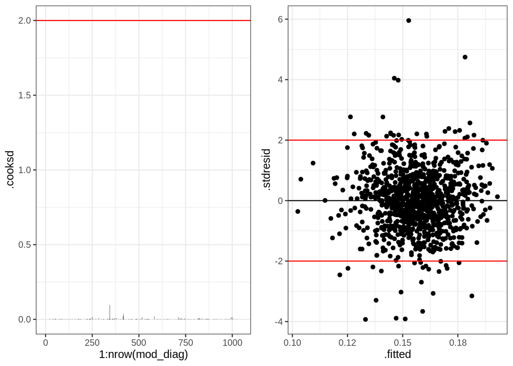

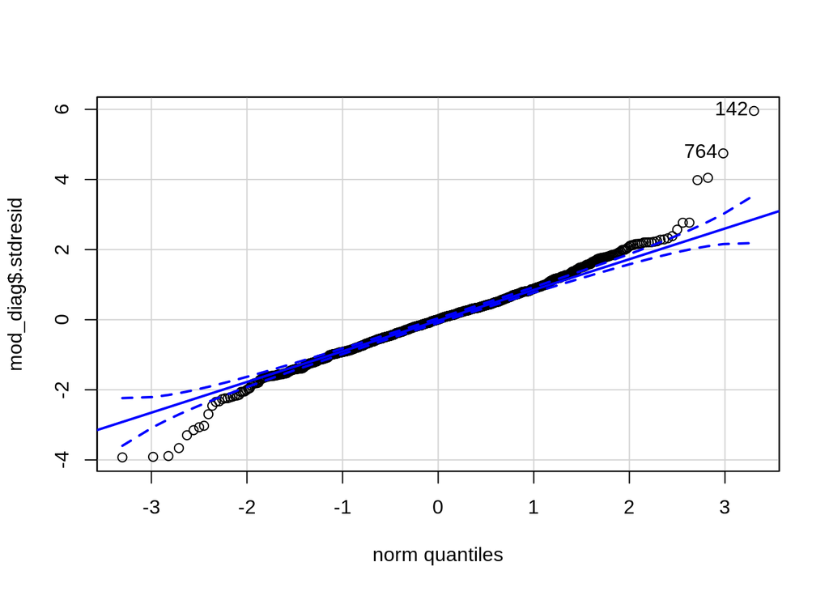

```
## [1] 142 764
```

But we have problem with residuals, and also global chack were failed! So despite our model good predict ERBB4_N by other protein, we can not name it correct

### Principal component analyses

```
##
## Call:
## rda(X = cortex_data_NA_cast_only_protein, scale = TRUE)
##
## Partitioning of correlations:
##               Inertia Proportion
## Total              71          1
## Unconstrained      71          1
##
## Eigenvalues, and their contribution to the correlations
##
## Importance of components:
##                          PC1    PC2   PC3    PC4    PC5    PC6    PC7    PC8
## Eigenvalue            19.805 11.609 7.899 5.4709 3.4708 3.3280 2.4253 2.1200
## Proportion Explained   0.279  0.164 0.111 0.0771 0.0489 0.0469 0.0342 0.0299
## Cumulative Proportion  0.279  0.442 0.554 0.6308 0.6797 0.7265 0.7607 0.7905
##                          PC9   PC10   PC11   PC12   PC13   PC14    PC15    PC16
## Eigenvalue            1.6476 1.2332 1.0304 0.8897 0.7296 0.7148 0.63245 0.56645
## Proportion Explained  0.0232 0.0174 0.0145 0.0125 0.0103 0.0101 0.00891 0.00798
## Cumulative Proportion 0.8137 0.8311 0.8456 0.8582 0.8684 0.8785 0.88741 0.89539
##                          PC17    PC18    PC19    PC20    PC21    PC22    PC23
## Eigenvalue            0.49503 0.46621 0.41811 0.40906 0.37723 0.36316 0.31898
## Proportion Explained  0.00697 0.00657 0.00589 0.00576 0.00531 0.00511 0.00449
## Cumulative Proportion 0.90236 0.90893 0.91482 0.92058 0.92589 0.93101 0.93550
##                         PC24    PC25    PC26    PC27    PC28    PC29    PC30
## Eigenvalue            0.2983 0.28676 0.26233 0.23911 0.22289 0.20109 0.18640
## Proportion Explained  0.0042 0.00404 0.00369 0.00337 0.00314 0.00283 0.00263
## Cumulative Proportion 0.9397 0.94374 0.94744 0.95080 0.95394 0.95677 0.95940
##                          PC31   PC32    PC33    PC34    PC35    PC36    PC37
## Eigenvalue            0.17668 0.1704 0.16695 0.14478 0.14039 0.12712 0.12158
## Proportion Explained  0.00249 0.0024 0.00235 0.00204 0.00198 0.00179 0.00171
## Cumulative Proportion 0.96189 0.9643 0.96664 0.96868 0.97066 0.97245 0.97416
##                          PC38    PC39    PC40    PC41    PC42    PC43   PC44
## Eigenvalue            0.11784 0.11296 0.10980 0.10715 0.10006 0.08842 0.0851
## Proportion Explained  0.00166 0.00159 0.00155 0.00151 0.00141 0.00125 0.0012
## Cumulative Proportion 0.97582 0.97741 0.97896 0.98047 0.98188 0.98312 0.9843
##                          PC45    PC46    PC47   PC48     PC49     PC50     PC51
## Eigenvalue            0.08306 0.07928 0.07487 0.0714 0.066829 0.061471 0.060016
## Proportion Explained  0.00117 0.00112 0.00105 0.0010 0.000941 0.000866 0.000845
## Cumulative Proportion 0.98549 0.98661 0.98766 0.9887 0.989606 0.990472 0.991317
```

[output cut: 30 more lines]

```
## NR2A_N   -1.542  0.651  0.219  0.7055  0.141 -0.1372
## pAKT_N   -1.097 -1.017 -0.576 -0.7469  0.184  0.3316
## ....
##
##
## Site scores (weighted sums of species scores)
##
##          PC1   PC2    PC3    PC4   PC5    PC6
## sit1 -0.4959 0.727 -0.331 0.4898 0.372 -0.316
## sit2 -0.3086 0.723 -0.163 0.3570 0.280 -0.230
## sit3 -0.3213 0.758 -0.116 0.2815 0.294 -0.176
## sit4 -0.0523 0.527 -0.487 0.1725 0.414 -0.244
## sit5  0.0721 0.557 -0.269 0.0757 0.363 -0.179
## sit6  0.0730 0.584 -0.308 0.0843 0.464 -0.127
## ....
```

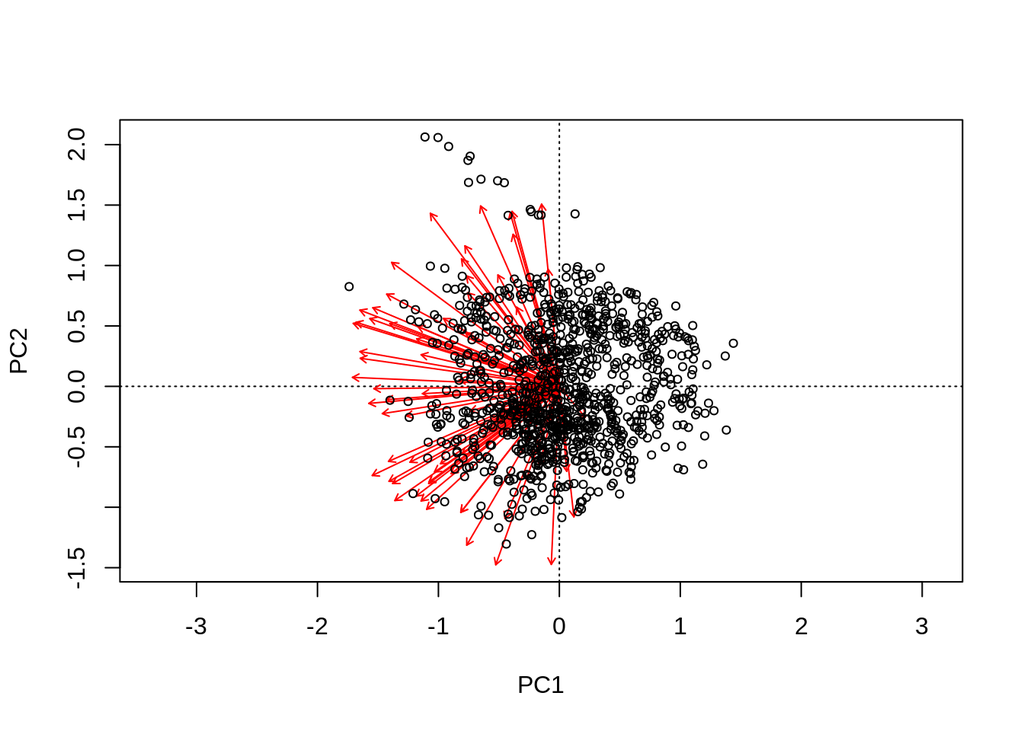

```
##  PC1  PC2  PC3  PC4  PC5  PC6  PC7  PC8  PC9 PC10 PC11 PC12 PC13 PC14 PC15 PC16
## 19.8 11.6  7.9  5.5  3.5  3.3  2.4  2.1  1.6  1.2  1.0  0.9  0.7  0.7  0.6  0.6
## PC17 PC18 PC19 PC20 PC21 PC22 PC23 PC24 PC25 PC26 PC27 PC28 PC29 PC30 PC31 PC32
##  0.5  0.5  0.4  0.4  0.4  0.4  0.3  0.3  0.3  0.3  0.2  0.2  0.2  0.2  0.2  0.2
## PC33 PC34 PC35 PC36 PC37 PC38 PC39 PC40 PC41 PC42 PC43 PC44 PC45 PC46 PC47 PC48
##  0.2  0.1  0.1  0.1  0.1  0.1  0.1  0.1  0.1  0.1  0.1  0.1  0.1  0.1  0.1  0.1
## PC49 PC50 PC51 PC52 PC53 PC54 PC55 PC56 PC57 PC58 PC59 PC60 PC61 PC62 PC63 PC64
##  0.1  0.1  0.1  0.1  0.1  0.0  0.0  0.0  0.0  0.0  0.0  0.0  0.0  0.0  0.0  0.0
## PC65 PC66 PC67 PC68 PC69 PC70
##  0.0  0.0  0.0  0.0  0.0  0.0
```

```
##   PC1   PC2   PC3   PC4   PC5   PC6   PC7   PC8   PC9  PC10  PC11  PC12  PC13
## 4.902 3.888 3.380 3.042 2.789 2.586 2.417 2.272 2.145 2.032 1.931 1.839 1.754
##  PC14  PC15  PC16  PC17  PC18  PC19  PC20  PC21  PC22  PC23  PC24  PC25  PC26
## 1.676 1.604 1.536 1.473 1.413 1.357 1.303 1.253 1.204 1.158 1.114 1.072 1.031
##  PC27  PC28  PC29  PC30  PC31  PC32  PC33  PC34  PC35  PC36  PC37  PC38  PC39
## 0.992 0.955 0.919 0.884 0.850 0.817 0.785 0.755 0.725 0.696 0.668 0.640 0.614
##  PC40  PC41  PC42  PC43  PC44  PC45  PC46  PC47  PC48  PC49  PC50  PC51  PC52
## 0.588 0.562 0.537 0.513 0.490 0.467 0.444 0.422 0.401 0.379 0.359 0.338 0.319
##  PC53  PC54  PC55  PC56  PC57  PC58  PC59  PC60  PC61  PC62  PC63  PC64  PC65
## 0.299 0.280 0.261 0.243 0.225 0.207 0.189 0.172 0.155 0.139 0.122 0.106 0.090
##  PC66  PC67  PC68  PC69  PC70
## 0.075 0.059 0.044 0.029 0.014
```

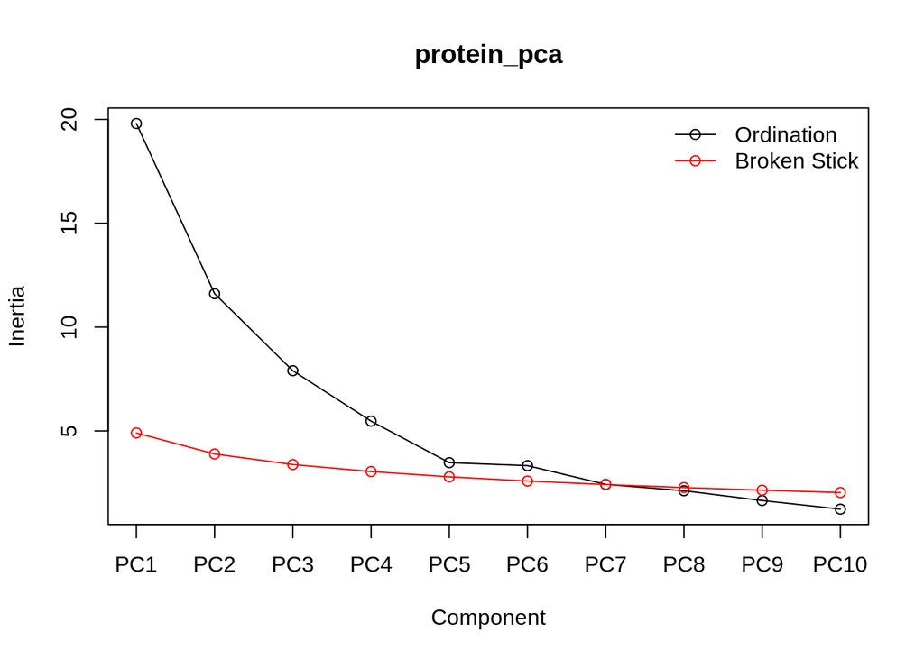

We can see that in good situation we should use 6 or 7 components

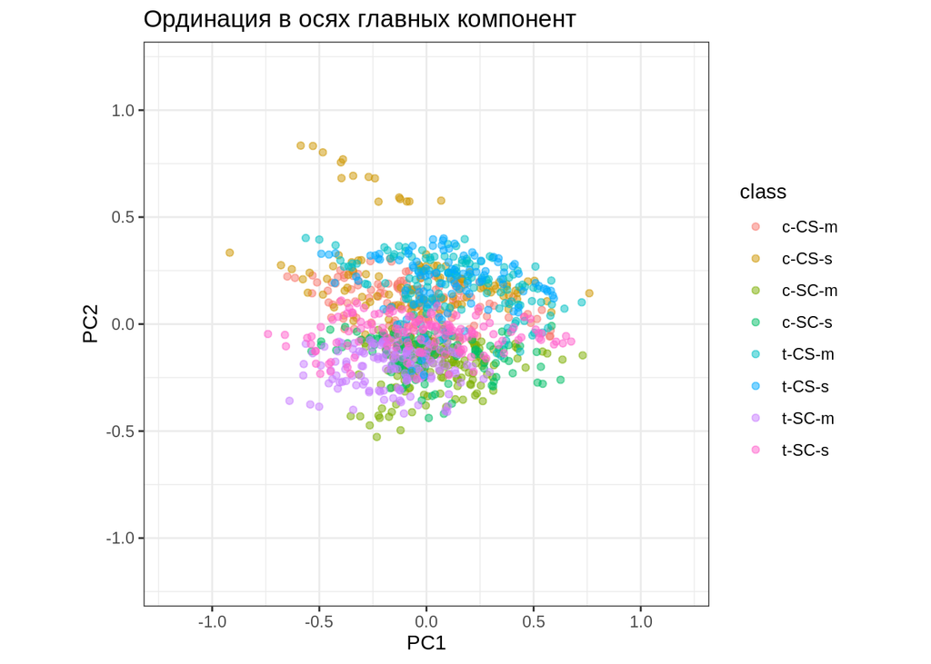

You can see 3d graph (with first 3 component) in RMarkdown, by starting code in chunk below

```
## [1] 0.30 0.28 0.20
## Creating new device
```

### nMDS

```
## 'comm' has negative data: 'autotransform', 'noshare' and 'wascores' set to FALSE
```

```
## *** No convergence -- monoMDS stopping criteria:
##     12: stress ratio > sratmax
##      8: scale factor of the gradient < sfgrmin
```

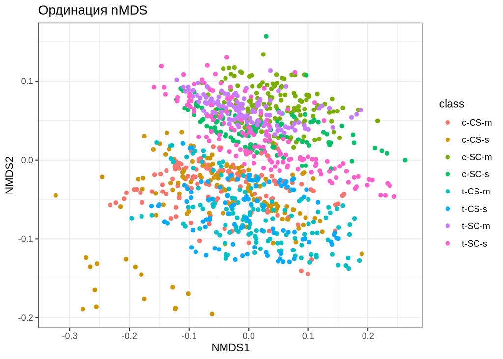

Overall we can see that there are differents in proteins counts in classes. But stress level is high enoth.

### Search for differentially expressed proteins by limma

We can see all proteins that differentially expressed in classes

[output not shown]

Futher by changing group we could understand what factor influenced for each protein (we should get Treatment or Genotype instead class)